# part-2-udacity-project-3-slide-deck-notebook-3 slides

## **Udacity Project 3 - Data Visualization**

## **Factors Affecting The Number of Bike Rides and Bike Ride Duration**

### Investigation Overview

The aim of this data visualization project is to use visualizations to determine and communicate the factors affecting the daily number of bike rides, ride durations and distance and to determine who the riders are:what are their ages, gender, location?

### Dataset Overview

The questions above will be answered using Ford GoBike Data from the month of February 2019. Ford GoBike is a bike sharing service in the Greater Bay Area of San Francisco, USA. The dataset consists of records of about 183,000 rides. The data features include duration of the rides, the location of the stations where the bike trip started and ended, the datetime, anonymized customer information such as customer type, birth year and gender and some other additional variables.

## Investigation Questions

- How do bike usage patterns vary by time of day and day of the week?
- What are the most popular bike routes in the Bay Area?
- How does the duration of bike trips vary based on factors like age and gender?
- How long does the average bike ride take?
- What factors affect the length of a bike ride?
- Do weather conditions such as temperature and rainfall affect the daily number of trips?

## **Ride Duration Distribution**

The ride durations have a log-normal distribution with a very slight skew to the right

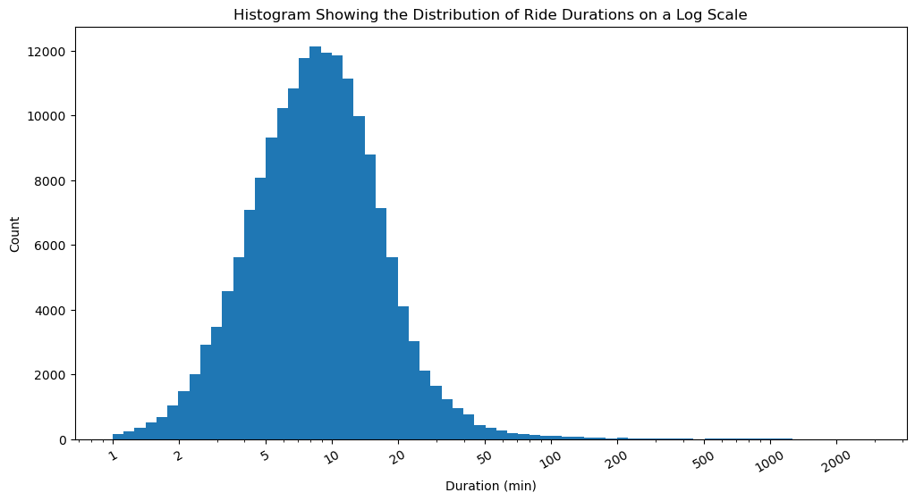

### **Age Distribution**

The distribution of the ages of shows that most of the riders are primarily the working age population of about 20 to 60. About 50 percent of the riders are within the ages of 25 to 35

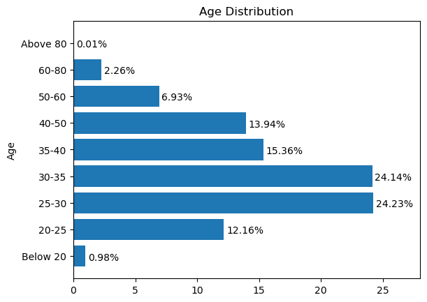

### **Distribution of Number of Rides by Day of The Week**

The weekdays recorded higher number of trips compared to the weekend with Thursday which recorded the highest average number of trips recording twice as many trips as the averages recorded on Saturday and Sunday. Among the weekdays, Monday had the lowest average number of trips, followed by Friday.

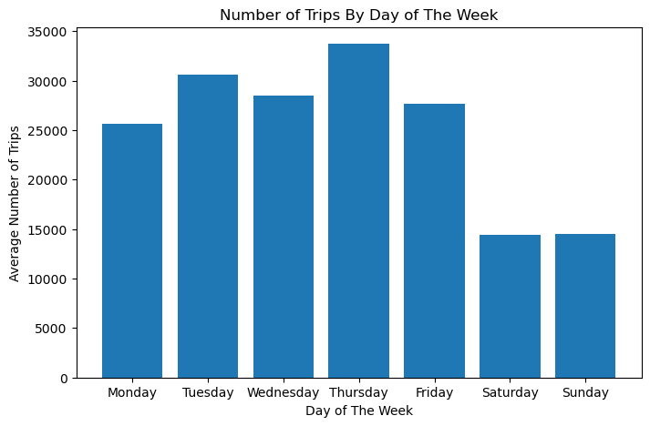

### **Ride Duration by Region**

The bar plot shows the region of the ride as one of the determinants of the duration of the ride. The average ride duration in East San Jose region is slightly less than 9 minutes while the average ride duration in North San Jose region is slightly less than 15 minutes. The rides that involved crossing from one region to another were the longest.

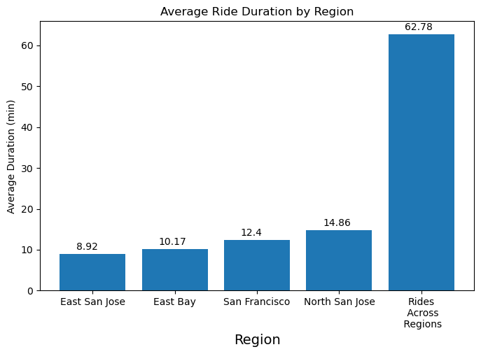

The number of rides per hour shows an expected pattern. The rides are highest during the morning and evening commute hours (around 6-9 am and 4-6pm). The night hours record the lowest number of trips especially after 12am and before 5am, at which most people are asleep. During the working hours of the day between 9am to 4pm, the number of trips is also relatively high.

Between 6am to to 8am, more trips start than end as more people start their commutes from home while from 9am to 10am, more trips end than start as most of the people reach their places of work. During the evening commute peak hours, from 3pm to 5pm, more trips start than end as most people start their trips from their places of work to go home while from 6pm to late into the night, 11pm , more trips end than start as more people reach their homes from their places of work.

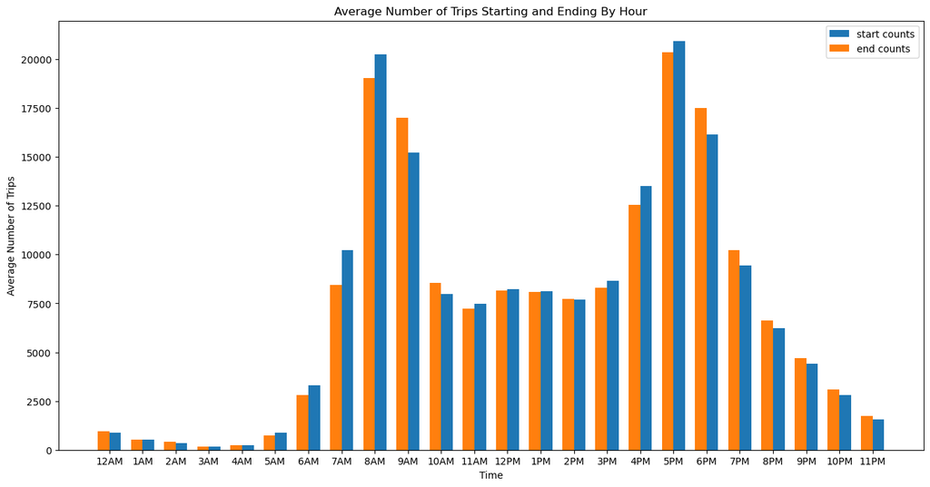

## **Factors Affecting Daily Number of Trips**

- Rainfall significantly affects the number of trips, especially on the first day when there is a sudden increase the precipitation levels
- The number of trips are significantly lower on the holidays and weekends.
- During the weekdays, the number of rides peak twice : during the morning and evening commute hours while during the weekends and holidays, the number of rides peak once during the day in the afternoon

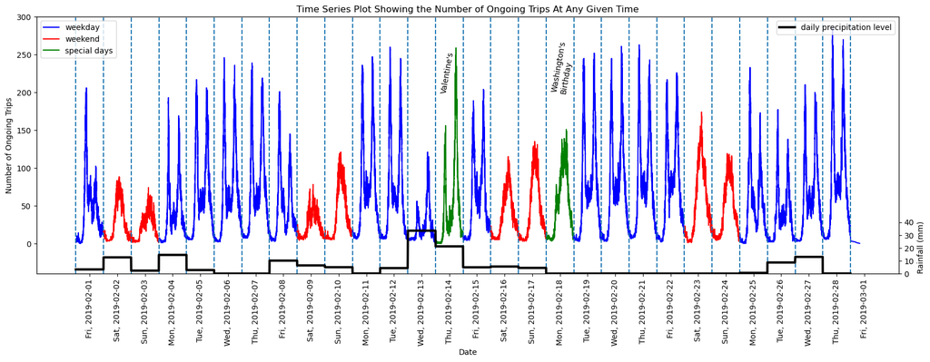